## Prova di Statistica (CLEA E CLEAM)

Scrivere in stampatello

| COGNOME | $\LARGE\square$ | $\LARGE\square$ | $\LARGE\square$ | $\LARGE\square$ | $\LARGE\square$ | $\LARGE\square$ | $\LARGE\square$ | $\LARGE\square$ | $\LARGE\square$ | $\LARGE\square$ | $\LARGE\square$ | $\LARGE\square$ | $\LARGE\square$ | $\LARGE\square$ | $\LARGE\square$ | $\LARGE\square$ | $\LARGE\square$ | $\LARGE\square$ | $\LARGE\square$ | $\LARGE\square$ |
| --- | --- | --- | --- | --- | --- | --- | --- | --- | --- | --- | --- | --- | --- | --- | --- | --- | --- | --- | --- | --- |
| NOME | $\LARGE\square$ | $\LARGE\square$ | $\LARGE\square$ | $\LARGE\square$ | $\LARGE\square$ | $\LARGE\square$ | $\LARGE\square$ | $\LARGE\square$ | $\LARGE\square$ | $\LARGE\square$ | $\LARGE\square$ | $\LARGE\square$ | $\LARGE\square$ | $\LARGE\square$ | $\LARGE\square$ | $\LARGE\square$ | $\LARGE\square$ | $\LARGE\square$ | $\LARGE\square$ | $\LARGE\square$ |
| Matricola | $\LARGE\square$ | $\LARGE\square$ | $\LARGE\square$ | $\LARGE\square$ | $\LARGE\square$ | $\LARGE\square$ | $\LARGE\square$ | $\LARGE\square$ | $\LARGE\square$ | $\LARGE\square$ | $\LARGE\square$ | $\LARGE\square$ | $\LARGE\square$ | $\LARGE\square$ | $\LARGE\square$ | $\LARGE\square$ | $\LARGE\square$ | $\LARGE\square$ | $\LARGE\square$ | $\LARGE\square$ |
| Codice | A | A | 4 | 7 | 8 | R | M | X |  |  |  |  |  |  |  |  |  |  |  |  |

### Esercizio 1

| $[\text{x}_j,$ | $\text{x}_{j+1})$ | $n_j$ |
| --- | --- | --- |
| 0.0 | 1.5 | 214 |
| 1.5 | 3.0 | 142 |
| 3.0 | 5.0 | 83 |
| 5.0 | 10.0 | 60 |
|  |  | 499 |

1.a **(Punti 14/56; 7.75/31)** Disegnare l’istogramma di densità percentuale.

| $[\text{x}_j,$ | $\text{x}_{j+1})$ | $n_j$ | $f_j$ | $b_j$ | $h_j$ |
| --- | --- | --- | --- | --- | --- |
| 0.0 | 1.5 | 214 | 0.4289 | 1.5 | 28.590 |
| 1.5 | 3.0 | 142 | 0.2846 | 1.5 | 18.971 |
| 3.0 | 5.0 | 83 | 0.1663 | 2.0 | 8.317 |
| 5.0 | 10.0 | 60 | 0.1202 | 5.0 | 2.405 |
|  |  | 499 | 1.0000 | 10.0 |  |

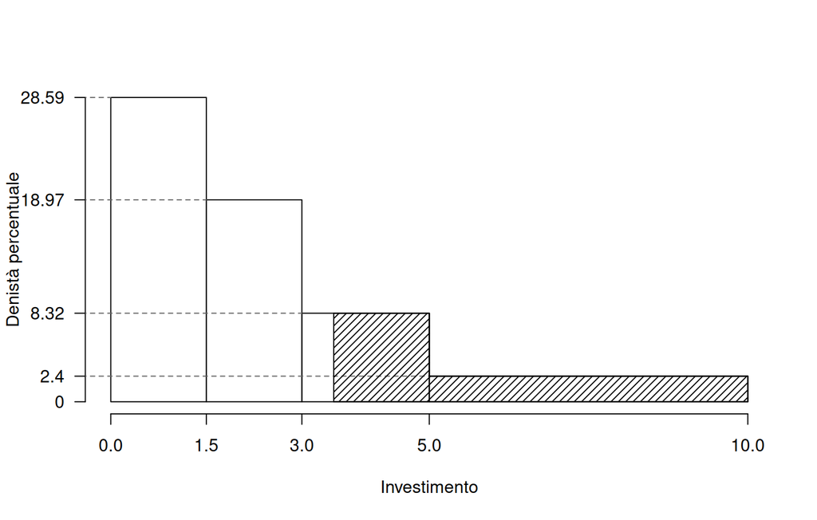

1.b **(Punti 3/56; 1.66/31)** Che percentuale di imprese hanno investito più di 3.5 milioni di euro negli ultimi 10 anni?

$$\begin{eqnarray*}
\%(X> 3.5 ) &=& ( 5 - 3.5 )\times h_{ 3 }+ f_{ 4 }\times
100 \\
&=& ( 1.5 )\times 8.317 + ( 0.1202 )\times 100 \\
&=& 0.245 \times(100)\\
\#(X> 3.5 ) &\approx& 122
\end{eqnarray*}$$

1.c **(Punti 2/56; 1.11/31)** Che relazione dobbiamo aspettarci tra media, mediana e moda?

1.d **(Punti 2/56; 1.11/31)** L’investimento medio è pari a $\bar x=2.5$, mentre la varianza è pari a $\sigma^2=4.7$. Se ogni impresa aumentasse il proprio investimento del 5%, quanto varrebbero la media e la varianza dei dati così trasformati?

### Esercizio 2

Un’azienda che produce macchinari per imballaggio ha due stabilimenti $A$ e $B$, nello stabilimento $A$ il numero di macchinari prodotti a settimana è distribuito come una Poisson di parametro 1.5 $X_A\sim\text{Pois}(1.5)$, mentre nello stabilimento $B$ il numero di macchinari prodotti a settimana è distribuito come una Poisson di parametro 0.8 $X_B\sim\text{Pois}(0.8)$, $X_A$ e $X_B$ indipendenti.

2.a **(Punti 14/56; 7.75/31)** Calcolare la probabilità che il totale prodotto ($X_A + X_B$) in una settimana sia maggiore o uguale a due.

$$X_A + X_B \sim \text{Pois}(1.5+0.8)$$
$$\begin{eqnarray*}
P( X_A+X_B \geq 2 ) &=& 1-P( X_A+X_B < 2 )
\\ &=& 1-\left( \frac{ 2.3 ^{ 0 }}{ 0 !}e^{- 2.3
}+\frac{ 2.3 ^{ 1 }}{ 1 !}e^{- 2.3 }
\right)\\ &=& 1-( 0.1003+0.2306
)\\ &=& 1- 0.3309
\\ &=& 0.6691
\end{eqnarray*}$$

2.b **(Punti 3/56; 1.66/31)** Calcolare la probabilità che $X_A + X_B< 2$ per 4 settimane consecutive

$$\begin{eqnarray*}
P(X_A + X_B < 2) &=& 1 - P(X_A + X_B \ge 2) \\
&=& 1 - 0.6691=0.3309\\
P(\text{4 volte}\{X_A + X_B < 2\}) &=& P(X_A + X_B <
2)^4\\
&=& 0.3309^4\\
&=& 0.012
\end{eqnarray*}$$

2.c **(Punti 2/56; 1.11/31)** Sia $Z\sim N(0,1)$ e $Y\sim \chi^2_4$, $Z$ e $Y$ indipendenti. Come si distribuisce
$$\frac{Z}{\sqrt{Y/4}} ~~~?$$

$$\frac{Z}{\sqrt{Y/4}} \sim t_4 ~~~~\text{è una $t$ di Sudent con 4 gradi
di libertà}$$

2.d **(Punti 2/56; 1.11/31)** Sia $X$ una VC e siano $A=\{X\le 1.5\}$ e $B=\{X > 3.2\}$. Posto $P(A)=0.15$ e $P(B)=0.05$, calcolare $P(\bar A\cap \bar B)$. (suggerimento: individuare $A$ e $B$ sulla retta reale)

Anzitutto notiamo che
$$\bar A=\overline{\{X\le 1.5\}} = \{X>1.5\},~~~~ \bar
B=\overline{\{X> 3.2\}} = \{X\le3.2\}.$$
e quindi
$$\bar A\cap\bar B= \{X>1.5\}\cap\{X\le3.2\} =\{1.5<X\le 3.2\}$$
inoltre
$$\overline{\bar A\cap\bar B}= \{X\le1.5\}\cup\{X>3.2\}$$
da cui
$$\begin{eqnarray*}
P(\bar A\cap \bar B) &=& P(1.5 < X \le 3.2) \\
&=& 1 - P({X\le 1.5}\cup{X > 3.2})\\
&=& 1 - (P(X\le 1.5)+P(X > 3.2))\\
&=& 1 - (0.15 + 0.05)\\
&=& 0.8
\end{eqnarray*}$$
Se la coda di sinistra ha probabilità 0.15 e quella di destra probabilita 0.05 al centro resta lo 0.8.

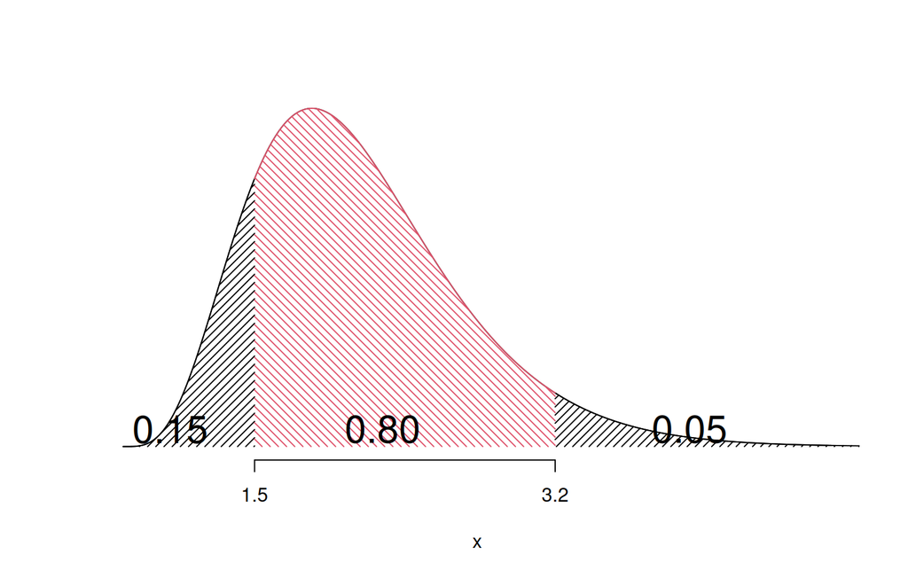

### Esercizio 3

3.a **(Punti 14/56; 7.75/31)** Un’urna contiene 3 palline numerate con $\fbox{0}$, 3 numerate con $\fbox{1}$ e 2 numerate con $\fbox{2}$. Si vince se esce $\fbox{2}$ e si perde altrimenti. Si estrae 100 volte con reinserimento. Qual è la probabilità di vincere almeno 30 volte?

**Teorema del Limite Centrale (somma di Bernoulli)**

Siano $X_1$,…,$X_n$, $n=100$ VC IID, tc $X_i\sim\text{Ber}(\pi=0.25)$$,\forall i$, posto:
$$S_n = X_1 + ... + X_n$$
allora:
$$\begin{eqnarray*}
S_n & \mathop{\sim}\limits_{a}& N(n\pi,n\pi(1-\pi)) \\
&\sim & N(100\cdot0.25,100\cdot0.25\cdot(1-0.25)) \\
&\sim & N(25,18.75)
\end{eqnarray*}$$
$$\begin{eqnarray*}
P( S_n > 30 )
&=& P\left( \frac { S_n - n\pi }{ \sqrt{n\pi(1-\pi)}
} > \frac { 30 - 25 }{\sqrt{ 18.75 }} \right) \\
&=& P\left( Z > 1.15 \right)
\\ &=& 1-P(Z< 1.15 )\\
&=& 1-\Phi( 1.15 ) \\ &=& 0.1251
\end{eqnarray*}$$

## Prova di Statistica (CLEA E CLEAM)

Scrivere in stampatello

| COGNOME | $\LARGE\square$ | $\LARGE\square$ | $\LARGE\square$ | $\LARGE\square$ | $\LARGE\square$ | $\LARGE\square$ | $\LARGE\square$ | $\LARGE\square$ | $\LARGE\square$ | $\LARGE\square$ | $\LARGE\square$ | $\LARGE\square$ | $\LARGE\square$ | $\LARGE\square$ | $\LARGE\square$ | $\LARGE\square$ | $\LARGE\square$ | $\LARGE\square$ | $\LARGE\square$ | $\LARGE\square$ |
| --- | --- | --- | --- | --- | --- | --- | --- | --- | --- | --- | --- | --- | --- | --- | --- | --- | --- | --- | --- | --- |
| NOME | $\LARGE\square$ | $\LARGE\square$ | $\LARGE\square$ | $\LARGE\square$ | $\LARGE\square$ | $\LARGE\square$ | $\LARGE\square$ | $\LARGE\square$ | $\LARGE\square$ | $\LARGE\square$ | $\LARGE\square$ | $\LARGE\square$ | $\LARGE\square$ | $\LARGE\square$ | $\LARGE\square$ | $\LARGE\square$ | $\LARGE\square$ | $\LARGE\square$ | $\LARGE\square$ | $\LARGE\square$ |
| Matricola | $\LARGE\square$ | $\LARGE\square$ | $\LARGE\square$ | $\LARGE\square$ | $\LARGE\square$ | $\LARGE\square$ | $\LARGE\square$ | $\LARGE\square$ | $\LARGE\square$ | $\LARGE\square$ | $\LARGE\square$ | $\LARGE\square$ | $\LARGE\square$ | $\LARGE\square$ | $\LARGE\square$ | $\LARGE\square$ | $\LARGE\square$ | $\LARGE\square$ | $\LARGE\square$ | $\LARGE\square$ |
| Codice | W | B | I | R | 9 | W | T | S |  |  |  |  |  |  |  |  |  |  |  |  |

### Esercizio 1

Su un campione di $50$ piccole imprese meccaniche dell’Emilia-Romagna è stato rilevato l’utile realizzato nel periodo pandemico (espresso in migliaia di euro). Di seguito è riportata la distribuzione delle frequenze relative:

| $[\text{x}_j,$ | $\text{x}_{j+1})$ | $f_j$ |
| --- | --- | --- |
| -10 | -5 | 0.06 |
| -5 | -1 | 0.18 |
| -1 | 2 | 0.70 |
| 2 | 5 | 0.06 |
|  |  | 1.00 |

1.a **(Punti 14/56; 7.75/31)** Disegnare l’istogramma di densità percentuale.

| $[\text{x}_j,$ | $\text{x}_{j+1})$ | $n_j$ | $f_j$ | $b_j$ | $h_j$ |
| --- | --- | --- | --- | --- | --- |
| -10 | -5 | 3 | 0.06 | 5 | 1.20 |
| -5 | -1 | 9 | 0.18 | 4 | 4.50 |
| -1 | 2 | 35 | 0.70 | 3 | 23.33 |
| 2 | 5 | 3 | 0.06 | 3 | 2.00 |
|  |  | 50 | 1.00 | 15 |  |

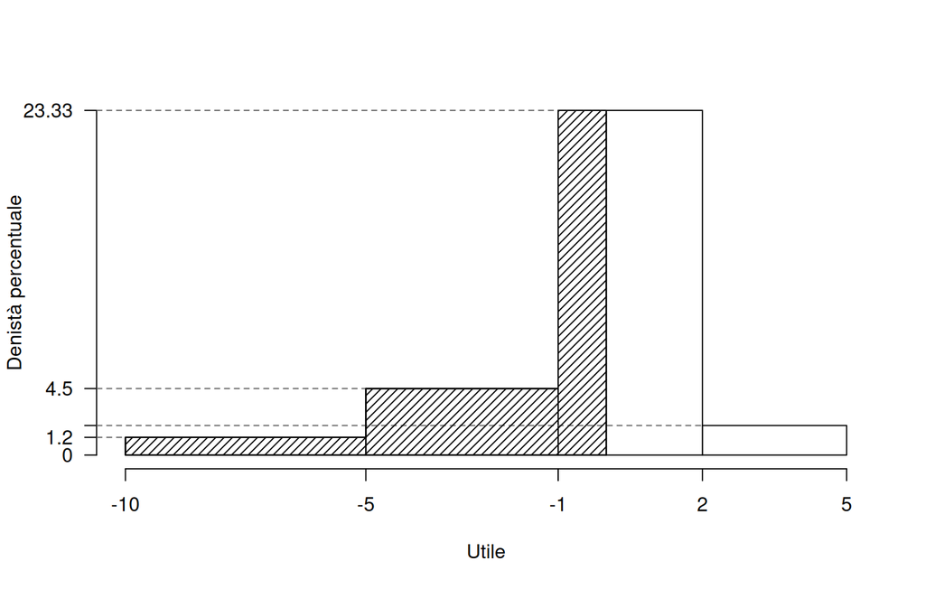

1.b **(Punti 3/56; 1.66/31)** Calcolare il numero di imprese con utile negativo

$$\begin{eqnarray*}
\%(X< 0 ) &=& f_{ 1 }\times 100+f_{ 2 }\times 100 +( 0
- -1 )\times h_{ 3 } \\
&=& ( 0.06 )\times 100+( 0.18 )\times 100 +( 1
)\times 23.33 \\
&=& 0.4733 \times(100) \\
\#(X< 0 ) &\approx& 24
\end{eqnarray*}$$

1.c **(Punti 2/56; 1.11/31)** Che relazione dobbiamo aspettarci tra media, mediana e moda?

1.d **(Punti 2/56; 1.11/31)** Si consideri la funzione
$$g(x) = (2.1-x)^2+(3.4-x)^2+(6.3-x)^2$$
Per quale valore di $x$, $g$ è minima?

### Esercizio 2

2.a **(Punti 14/56; 7.75/31)** Un’urna contiene tre palline: 2 Rosse e 1 Nera. Si estrae 2 volte senza reimmissione. Si vince se si ottengono 2 Rosse. Si rimettono le palline nell’urna e si ripete il gioco 6 volte. Qual è la probabilità di vincere almeno 5 volte su 6 giocate?

$$P(R_1\cap R_2)=\frac 23\cdot\frac 12 = \frac 13$$
$$\begin{eqnarray*}
P( X \geq 5 ) &=& \binom{ 6 }{ 5 } 0.3333 ^{ 5 }(1- 0.3333
)^{ 6 - 5 }+\binom{ 6 }{ 6 } 0.3333 ^{ 6 }(1- 0.3333 )^{ 6 - 6 }
\\ &=& 0.0165+0.0014
\\ &=& 0.0179
\end{eqnarray*}$$

2.b **(Punti 3/56; 1.66/31)** Un’urna contiene tre palline: 2 Rosse e 1 Nera. Si estrae 2 volte senza reimmissione. Si vince se si ottengono 2 Rosse. Si rimettono le palline nell’urna e si ripete finché non si vince una volta. Qual è la probabilità di finire dopo 4 giocate?

$$\begin{eqnarray*}
P(\text{finire in 4 giocate}) &=&
P(X_1=0)P(X_2=0)P(X_3=0)P(X_4=1)\\
&=& \left(\frac 23\right)^3 \frac
13\\
&=& 0.0988
\end{eqnarray*}$$

2.c **(Punti 2/56; 1.11/31)** Siano $Z\sim N(0,1)$ e $Y\sim N(0,1)$, $Z$ e $Y$ indipendenti. Come si distribuisce
$$\frac{Z+Y}{2} ~~~?$$

$$\begin{eqnarray*}
\frac{Z+Y}{2} &=& \frac 12Z+\frac 12 Y\\
\frac 12Z+\frac 12 Y &\sim& N\left(0+0,\left(\frac
12\right)^2\cdot 1+\left(\frac 12\right)^2\cdot 1\right)\\
&\sim& N\left(0,\frac 12\right)
\end{eqnarray*}$$

2.d **(Punti 2/56; 1.11/31)** Sia $X$ una VC e siano $A=\{X\le 1.5\}$ e $B=\{X > 3.2\}$. Posto $P(A)=0.15$ e $P(B)=0.05$, calcolare $P(A\cup B)$. (suggerimento: individuare $A$ e $B$ sulla retta reale)

$$\begin{eqnarray*}
P( A\cup B) &=& P({X\le 1.5}\cup{X > 3.2})\\
&=& P(X\le 1.5)+P(X > 3.2)\\
&=& 0.2
\end{eqnarray*}$$

### Esercizio 3

3.a **(Punti 14/56; 7.75/31)** Un’urna contiene 2 palline numerate con $\fbox{-1}$, 3 numerate con $\fbox{+1}$. Si estrae 1000 volte con reinserimento. Qual è la probabilità che la somma delle 1000 estrazioni sia minore di 180?

$$\begin{eqnarray*} \mu &=& E(X_i)
= \sum_{x\in S_X}x P(X=x)\\
&=& ( -1 ) \frac { 2 }{ 5 }+ 1 \frac { 3 }{ 5 } \\
&=& 0.2 \\
\sigma^2 &=& V(X_i) = \sum_{x\in S_X}x^2 P(X=x)-\mu^2\\
&=&\left( ( -1 ) ^2\frac { 2 }{ 5 }+ 1 ^2\frac { 3 }{ 5 }
\right)-( 0.2 )^2\\
&=& 0.96
\end{eqnarray*}$$
**Teorema del Limite Centrale (somma VC qualunque)**

Siano $X_1$,…,$X_n$, $n=1000$ VC IID, tc $E(X_i)=\mu=0.2$ e $V(X_i)=\sigma^2=0.96,\forall i$, posto:
$$S_n = X_1 + ... + X_n$$
allora:
$$\begin{eqnarray*}
S_n & \mathop{\sim}\limits_{a}& N(n\mu,n\sigma^2) \\
&\sim & N(1000\cdot0.2,1000\cdot0.96) \\
&\sim & N(200,960)
\end{eqnarray*}$$
$$\begin{eqnarray*}
P( S_n < 180 )
&=& P\left( \frac { S_n - n\mu }{ \sqrt{n\sigma^2}
} < \frac { 180 - 200 }{\sqrt{ 960 }} \right) \\
&=& P\left( Z < -0.65 \right) \\
&=& 1-\Phi( 0.65 ) \\ &=& 0.2578
\end{eqnarray*}$$

## Prova di Statistica (CLEA E CLEAM)

Scrivere in stampatello

| COGNOME | $\LARGE\square$ | $\LARGE\square$ | $\LARGE\square$ | $\LARGE\square$ | $\LARGE\square$ | $\LARGE\square$ | $\LARGE\square$ | $\LARGE\square$ | $\LARGE\square$ | $\LARGE\square$ | $\LARGE\square$ | $\LARGE\square$ | $\LARGE\square$ | $\LARGE\square$ | $\LARGE\square$ | $\LARGE\square$ | $\LARGE\square$ | $\LARGE\square$ | $\LARGE\square$ | $\LARGE\square$ |
| --- | --- | --- | --- | --- | --- | --- | --- | --- | --- | --- | --- | --- | --- | --- | --- | --- | --- | --- | --- | --- |
| NOME | $\LARGE\square$ | $\LARGE\square$ | $\LARGE\square$ | $\LARGE\square$ | $\LARGE\square$ | $\LARGE\square$ | $\LARGE\square$ | $\LARGE\square$ | $\LARGE\square$ | $\LARGE\square$ | $\LARGE\square$ | $\LARGE\square$ | $\LARGE\square$ | $\LARGE\square$ | $\LARGE\square$ | $\LARGE\square$ | $\LARGE\square$ | $\LARGE\square$ | $\LARGE\square$ | $\LARGE\square$ |
| Matricola | $\LARGE\square$ | $\LARGE\square$ | $\LARGE\square$ | $\LARGE\square$ | $\LARGE\square$ | $\LARGE\square$ | $\LARGE\square$ | $\LARGE\square$ | $\LARGE\square$ | $\LARGE\square$ | $\LARGE\square$ | $\LARGE\square$ | $\LARGE\square$ | $\LARGE\square$ | $\LARGE\square$ | $\LARGE\square$ | $\LARGE\square$ | $\LARGE\square$ | $\LARGE\square$ | $\LARGE\square$ |
| Codice | J | C | W | U | 7 | 1 | L | 2 |  |  |  |  |  |  |  |  |  |  |  |  |

### Esercizio 1

Un consorzio agroalimentare ha monitorato l’ammontare delle vendite mensili (in migliaia di euro) di un campione di 50 aziende agricole del Centro Italia, nel corso dell’anno 2023. Di seguito è riportata la distribuzione delle frequenze cumulate, raggruppate in classi di vendita.

| $[\text{x}_j,$ | $\text{x}_{j+1})$ | $F_j$ |
| --- | --- | --- |
| 0 | 5 | 0.06 |
| 5 | 7 | 0.34 |
| 7 | 8 | 0.66 |
| 8 | 10 | 0.94 |
| 10 | 15 | 1.00 |

1.a **(Punti 14/56; 7.75/31)** Disegnare l’istogramma delle densità percentuali.

| $[\text{x}_j,$ | $\text{x}_{j+1})$ | $n_j$ | $f_j$ | $b_j$ | $h_j$ |
| --- | --- | --- | --- | --- | --- |
| 0 | 5 | 3 | 0.06 | 5 | 1.2 |
| 5 | 7 | 14 | 0.28 | 2 | 14.0 |
| 7 | 8 | 16 | 0.32 | 1 | 32.0 |
| 8 | 10 | 14 | 0.28 | 2 | 14.0 |
| 10 | 15 | 3 | 0.06 | 5 | 1.2 |
|  |  | 50 | 1.00 | 15 |  |

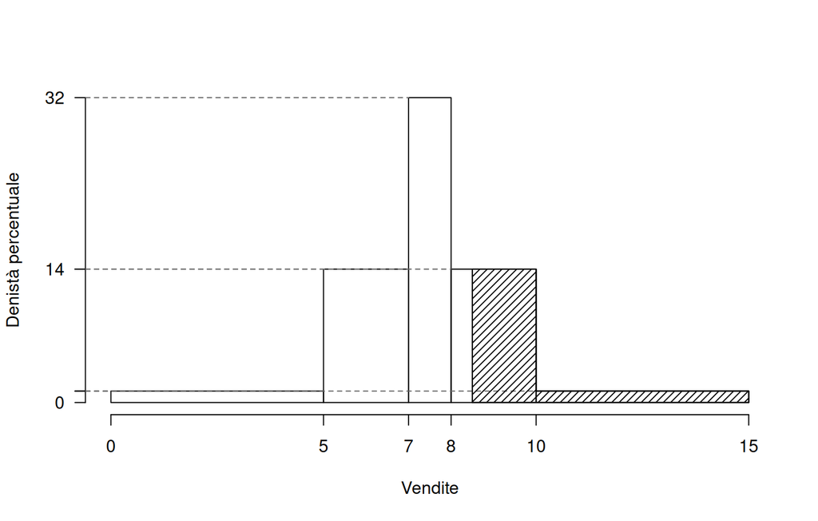

1.b **(Punti 3/56; 1.66/31)** Qual è la percentuale di aziende che hanno venduto più di 8.5 mila euro?

$$\begin{eqnarray*}
\%(X> 8.5 ) &=& ( 10 - 8.5 )\times h_{ 4 }+ f_{ 5
}\times 100 \\
&=& ( 1.5 )\times 14 + ( 0.06 )\times 100 \\
&=& 0.27 \times(100)\\
\#(X> 8.5 ) &\approx& 14
\end{eqnarray*}$$

1.c **(Punti 2/56; 1.11/31)** Che relazione dobbiamo aspettarci tra media, mediana e moda?

1.d **(Punti 2/56; 1.11/31)** Si consideri la funzione
$$g(x) = |2.1-x|+|3.4-x|+|6.3-x|+|7.1 -x| + |18.9-x|$$
Per quale valore di $x$, $g$ è minima?

### Esercizio 2

Due impianti industriali producono gas utile a un processo chimico. Le quantità giornaliere (in m³) sono $X \sim N(120,25)$ per l’impianto $I_1$ e $Y \sim N(80,16)$ per l’impianto $I_2$, $X$ e $Y$ indipendenti. L’impianto $I_1$ va in sovraccarico se $A=\{X> 130\}$, mentre l’impianto $I_2$ va in sovraccarico se $B=\{Y> 88\}$.

2.a **(Punti 14/56; 7.75/31)** Calcolare la probabilità che almeno uno dei due impianti vada in sovraccarico.

$$\begin{eqnarray*}
P( X > 130 )
&=& P\left( \frac { X - \mu_X }{ \sigma_X
} > \frac { 130 - 120 }{\sqrt{ 25 }} \right) \\
&=& P\left( Z > 2 \right)
\\ &=& 1-P(Z< 2 )\\
&=& 1-\Phi( 2 ) \\ &=& 0.0228
\end{eqnarray*}$$
$$\begin{eqnarray*}
P( Y > 88 )
&=& P\left( \frac { Y - \mu_Y }{ \sigma_Y
} > \frac { 88 - 80 }{\sqrt{ 16 }} \right) \\
&=& P\left( Z > 2 \right)
\\ &=& 1-P(Z< 2 )\\
&=& 1-\Phi( 2 ) \\ &=& 0.0228
\end{eqnarray*}$$
$$\begin{eqnarray*}
P(A\cup B) &=& P(A)+P(B)-P(A\cap B)\\
&=& P(A)+P(B)-P(A)P(B)\\
&=& 0.0228 + 0.0228 -0.0005\\
&=& 0.045
\end{eqnarray*}$$

2.b **(Punti 3/56; 1.66/31)** La produzione totale dell’impianto è data da $S=X+Y$. Calcolare $P(S>190|S<200)$.

$$\begin{eqnarray*}
S &\sim& N(120+80,25+16)\\
&\sim& N(200,41)\\
\{S>190\}\cap \{S<200\} &=& \{190< S< 200\}
\end{eqnarray*}$$
$$\begin{eqnarray*}
P( 190 < S \leq 200 ) &=& P\left( \frac { 190 - 200
}{\sqrt{ 41 }} < \frac { S - \mu_S }{ \sigma_S } \leq \frac {
200 - 200 }{\sqrt{ 41 }}\right) \\
&=& P\left( -1.56 < Z \leq 0 \right) \\
&=& \Phi( 0 )-\Phi( -1.56 )\\
&=& \Phi( 0 )-(1-\Phi( 1.56 )) \\
&=& 0.5 -(1- 0.9406 ) \\
&=& 0.4406
\end{eqnarray*}$$

$$\begin{eqnarray*}
P(S>190|S<200) &=& \frac{P(\{S>190\}\cap
\{S<200\})}{P(S<200)}\\
&=& \frac{P(190< S< 200)}{P(S<200)}\\
&=& \frac{0.4406}{0.5}\\
&=& 0.8812
\end{eqnarray*}$$

2.c **(Punti 2/56; 1.11/31)** Siano $X\sim \text{Ber}(\pi=0.3)$ e $Y\sim \text{Ber}(\pi=0.3)$, $X$ e $Y$ indipendenti. Come si distribuisce
$$X+Y~~~?$$

$$X+Y\sim \text{Binom}(n=2,\pi=0.3)$$

2.d **(Punti 2/56; 1.11/31)** Sia $X$ una VC e siano $A=\{X\le 1.5\}$ e $B=\{X > 3.2\}$. Posto $P(A)=0.15$ e $P(B)=0.05$, calcolare $P(\bar A\cup B)$. (suggerimento: individuare $A$ e $B$ sulla retta reale)

$$\begin{eqnarray*}
P( A\cup B) &=& P(\overline{\{X\le 1.5\}}\cup{X > 3.2})\\
&=& P(\{X> 1.5\}\cup{X > 3.2})\\
&=& P(X> 1.5)\\
&=& 1-P(X\le 1.5)\\
&=& 0.85
\end{eqnarray*}$$

### Esercizio 3

3.a **(Punti 14/56; 7.75/31)** Un’urna contiene 2 palline numerate con $\fbox{0}$, 6 numerate con $\fbox{1}$ e 2 numerate con $\fbox{2}$. Si estrae 100 volte con reinserimento. Qual è la probabilità che la proporzione di palline col numero $\fbox{1}$ sia minore di 0.55?

$$\pi = P(\text{estrarre $\fbox{1}$})=\frac {6}{10}=0.6$$
**Teorema del Limite Centrale (proporzione)**

Siano $X_1$,…,$X_n$, $n=100$ VC IID, tc $X_i\sim\text{Ber}(\pi=0.6)$$,\forall i$, posto:
$$\hat\pi=\frac{S_n}n = \frac{X_1 + ... + X_n}n$$
allora:
$$\begin{eqnarray*}
\hat\pi & \mathop{\sim}\limits_{a}& N(\pi,\pi(1-\pi)/n) \\
&\sim & N\left(0.6,\frac{0.6\cdot(1-0.6)}{100}\right) \\
&\sim & N(0.6,0.0024)
\end{eqnarray*}$$
$$\begin{eqnarray*}
P( \hat\pi < 0.55 )
&=& P\left( \frac { \hat\pi - \pi }{
\sqrt{\pi(1-\pi)/n} } < \frac { 0.55 - 0.6 }{\sqrt{ 0.0024 }}
\right) \\
&=& P\left( Z < -1.02 \right) \\
&=& 1-\Phi( 1.02 ) \\ &=& 0.1539
\end{eqnarray*}$$

## Prova di Statistica (CLEA E CLEAM)

Scrivere in stampatello

| COGNOME | $\LARGE\square$ | $\LARGE\square$ | $\LARGE\square$ | $\LARGE\square$ | $\LARGE\square$ | $\LARGE\square$ | $\LARGE\square$ | $\LARGE\square$ | $\LARGE\square$ | $\LARGE\square$ | $\LARGE\square$ | $\LARGE\square$ | $\LARGE\square$ | $\LARGE\square$ | $\LARGE\square$ | $\LARGE\square$ | $\LARGE\square$ | $\LARGE\square$ | $\LARGE\square$ | $\LARGE\square$ |
| --- | --- | --- | --- | --- | --- | --- | --- | --- | --- | --- | --- | --- | --- | --- | --- | --- | --- | --- | --- | --- |
| NOME | $\LARGE\square$ | $\LARGE\square$ | $\LARGE\square$ | $\LARGE\square$ | $\LARGE\square$ | $\LARGE\square$ | $\LARGE\square$ | $\LARGE\square$ | $\LARGE\square$ | $\LARGE\square$ | $\LARGE\square$ | $\LARGE\square$ | $\LARGE\square$ | $\LARGE\square$ | $\LARGE\square$ | $\LARGE\square$ | $\LARGE\square$ | $\LARGE\square$ | $\LARGE\square$ | $\LARGE\square$ |
| Matricola | $\LARGE\square$ | $\LARGE\square$ | $\LARGE\square$ | $\LARGE\square$ | $\LARGE\square$ | $\LARGE\square$ | $\LARGE\square$ | $\LARGE\square$ | $\LARGE\square$ | $\LARGE\square$ | $\LARGE\square$ | $\LARGE\square$ | $\LARGE\square$ | $\LARGE\square$ | $\LARGE\square$ | $\LARGE\square$ | $\LARGE\square$ | $\LARGE\square$ | $\LARGE\square$ | $\LARGE\square$ |
| Codice | O | D | D | R | 7 | 9 | A | P |  |  |  |  |  |  |  |  |  |  |  |  |

### Esercizio 1

Su un campione di $50$ imprese meccaniche dell’Emilia-Romagna è stato rilevato l’investimento effettuato negli ultimi 10 anni per gli obiettivi SDG (espresso in milioni di euro). Di seguito è riportata la distribuzione delle densità percentuali:

| $[\text{x}_j,$ | $\text{x}_{j+1})$ | $h_j$ |
| --- | --- | --- |
| 0.0 | 1.5 | 28.00 |
| 1.5 | 3.0 | 18.67 |
| 3.0 | 5.0 | 8.00 |
| 5.0 | 10.0 | 2.80 |

1.a **(Punti 14/56; 7.75/31)** Calcolare il valore approssimato della mediana.

| $[\text{x}_j,$ | $\text{x}_{j+1})$ | $n_j$ | $f_j$ | $b_j$ | $h_j$ | $F_j$ |
| --- | --- | --- | --- | --- | --- | --- |
| 0.0 | 1.5 | 21 | 0.42 | 1.5 | 28.00 | 0.42 |
| 1.5 | 3.0 | 14 | 0.28 | 1.5 | 18.67 | 0.70 |
| 3.0 | 5.0 | 8 | 0.16 | 2.0 | 8.00 | 0.86 |
| 5.0 | 10.0 | 7 | 0.14 | 5.0 | 2.80 | 1.00 |
|  |  | 50 | 1.00 | 10.0 |  |  |

$$\begin{eqnarray*}
p &=& 0.5 , \text{essendo }F_{ 2 }= 0.7 >
0.5 \Rightarrow j_{ 0.5 }= 2 \\
x_{ 0.5 } &=& x_{\text{inf}; 2 } + \frac{ { 0.5 } - F_{ 1 }}
{f_{ 2 }} \cdot b_{ 2 } \\
&=& 1.5 + \frac {{ 0.5 } - 0.42 } { 0.28 }
\cdot 1.5 \\
&=& 1.929
\end{eqnarray*}$$

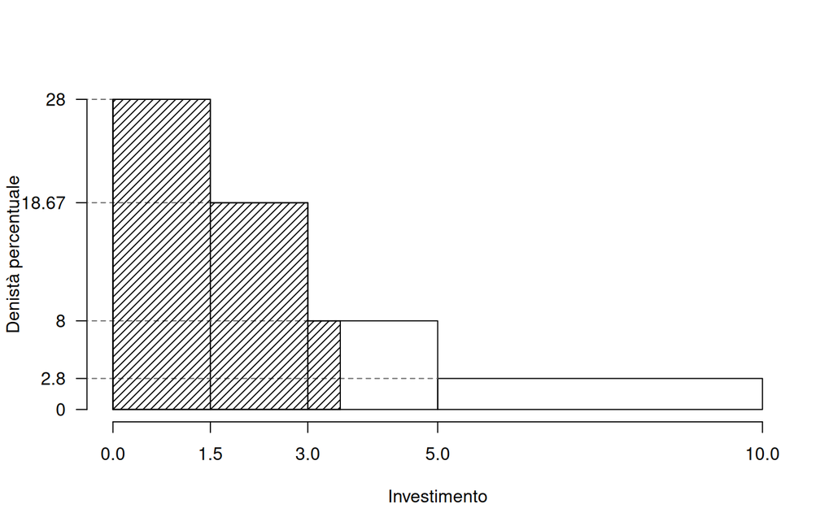

1.b **(Punti 3/56; 1.66/31)** Che percentuale di imprese ha investito meno di 3.5 milioni di euro negli ultimi 10 anni?

$$\begin{eqnarray*}
\%(X< 3.5 ) &=& f_{ 1 }\times 100+f_{ 2 }\times 100 +(
3.5 - 3 )\times h_{ 3 } \\
&=& ( 0.42 )\times 100+( 0.28 )\times 100 +( 0.5
)\times 8 \\
&=& 0.74 \times(100) \\
\#(X< 3.5 ) &\approx& 37
\end{eqnarray*}$$

1.c **(Punti 2/56; 1.11/31)** Individuare la classe modale, metterla in relazione con la mediana calcolata al punto 1a. La media aritmetica è maggiore o minore della mediana? Perché?

1.d **(Punti 2/56; 1.11/31)** Sulle $n_{ER}=50$ dell’Emilia-Romagna l’investimento medio è pari a $\bar x_{ER}=2.44$, mentre la standard deviation è pari a $SD_{ER}=2.0861$. La stessa indagine è stata condotta su un campione di $n_L=60$ imprese della Lombardia e ha evidenziato un investimento medio pari a $\bar x_{L}=2.79$ e una standard deviation pari a $SD_L = 2.0985$. Calcolare l’investimento medio complessivo, considerando insieme i due campioni.

### Esercizio 2

Un’urna contiene 10 palline: 4 Rosse, 4 Nere e 2 Bianche. Si estrae $n=5$ volte **con** reintroduzione.

2.a **(Punti 14/56; 7.75/31)** Calcolare la probabilità di ottenere al massimo due palline Rosse su $n = 5$ estrazioni,

$$\begin{eqnarray*}
P( X \leq 2 ) &=& \binom{ 5 }{ 0 } 0.4 ^{ 0 }(1- 0.4 )^{ 5
- 0 }+\binom{ 5 }{ 1 } 0.4 ^{ 1 }(1- 0.4 )^{ 5 - 1 }+\binom{ 5 }{ 2 }
0.4 ^{ 2 }(1- 0.4 )^{ 5 - 2 } \\ &=&
0.0778+0.2592+0.3456 \\ &=& 0.6826
\end{eqnarray*}$$

2.b **(Punti 3/56; 1.66/31)** Un’urna contiene 10 palline: 4 Rosse, 4 Nere e 2 Bianche. Si estrae 2 volte **senza** reintroduzione. Calcolare la probabilità di osservare Rosso alla seconda estrazione.

2.c **(Punti 2/56; 1.11/31)** Siano $Z\sim N(0,1)$ e $Y\sim N(0,1)$, $Z$ e $Y$ indipendenti. Come si distribuisce
$$X^2+Y^2 ~~~?$$

$$X^2+Y^2 \sim\chi^2_2 ~~~~\text{Chi-quadro con 2 gradi di libertà}$$

2.d **(Punti 2/56; 1.11/31)** Sia $X$ una VC e siano $A=\{X\le -1.5\}$ e $B=\{X > 1.2\}$. Posto $P(A)=0.05$ e $P(B)=0.05$, calcolare $P(\bar A\cup \bar B)$. (suggerimento: individuare $A$ e $B$ sulla retta reale)

$$\begin{eqnarray*}
P( \bar A\cup \bar B) &=& P(\overline{\{X\le
-1.5\}}\cup\overline{\{X > 1.2\}})\\
&=& P(\{X> -1.5\} \cup \{X \le 1.2\})\\
&=& P(-\infty<X<+\infty)\\
&=& 1
\end{eqnarray*}$$

### Esercizio 3

3.a **(Punti 14/56; 7.75/31)** Un’urna contiene tre palline: 3 Rosse e 2 Nere. Si estrae 2 volte senza reimmissione. Si vince se si ottengono 2 Rosse. Si rimettono le palline nell’urna e si ripete il gioco 121 volte. Calcolare la probabilità di vincere almeno 35 volte.

$$P(R_1\cap R_2)=\frac 35\cdot\frac 24 = \frac 3{10}$$
**Teorema del Limite Centrale (somma di Bernoulli)**

Siano $X_1$,…,$X_n$, $n=121$ VC IID, tc $X_i\sim\text{Ber}(\pi=0.3)$$,\forall i$, posto:
$$S_n = X_1 + ... + X_n$$
allora:
$$\begin{eqnarray*}
S_n & \mathop{\sim}\limits_{a}& N(n\pi,n\pi(1-\pi)) \\
&\sim & N(121\cdot0.3,121\cdot0.3\cdot(1-0.3)) \\
&\sim & N(36.3,25.41)
\end{eqnarray*}$$
$$\begin{eqnarray*}
P( S_n > 35 )
&=& P\left( \frac { S_n - n\pi }{ \sqrt{n\pi(1-\pi)}
} > \frac { 35 - 36.3 }{\sqrt{ 25.41 }} \right) \\
&=& P\left( Z > -0.26 \right)
\\ &=& 1-P(Z< -0.26 )\\
&=& 1-(1-\Phi( 0.26 )) \\ &=& 0.6026
\end{eqnarray*}$$

## Prova di Statistica (CLEA E CLEAM)

Scrivere in stampatello

| COGNOME | $\LARGE\square$ | $\LARGE\square$ | $\LARGE\square$ | $\LARGE\square$ | $\LARGE\square$ | $\LARGE\square$ | $\LARGE\square$ | $\LARGE\square$ | $\LARGE\square$ | $\LARGE\square$ | $\LARGE\square$ | $\LARGE\square$ | $\LARGE\square$ | $\LARGE\square$ | $\LARGE\square$ | $\LARGE\square$ | $\LARGE\square$ | $\LARGE\square$ | $\LARGE\square$ | $\LARGE\square$ |
| --- | --- | --- | --- | --- | --- | --- | --- | --- | --- | --- | --- | --- | --- | --- | --- | --- | --- | --- | --- | --- |
| NOME | $\LARGE\square$ | $\LARGE\square$ | $\LARGE\square$ | $\LARGE\square$ | $\LARGE\square$ | $\LARGE\square$ | $\LARGE\square$ | $\LARGE\square$ | $\LARGE\square$ | $\LARGE\square$ | $\LARGE\square$ | $\LARGE\square$ | $\LARGE\square$ | $\LARGE\square$ | $\LARGE\square$ | $\LARGE\square$ | $\LARGE\square$ | $\LARGE\square$ | $\LARGE\square$ | $\LARGE\square$ |
| Matricola | $\LARGE\square$ | $\LARGE\square$ | $\LARGE\square$ | $\LARGE\square$ | $\LARGE\square$ | $\LARGE\square$ | $\LARGE\square$ | $\LARGE\square$ | $\LARGE\square$ | $\LARGE\square$ | $\LARGE\square$ | $\LARGE\square$ | $\LARGE\square$ | $\LARGE\square$ | $\LARGE\square$ | $\LARGE\square$ | $\LARGE\square$ | $\LARGE\square$ | $\LARGE\square$ | $\LARGE\square$ |
| Codice | H | E | V | F | C | 7 | 5 | 4 |  |  |  |  |  |  |  |  |  |  |  |  |

### Esercizio 1

Su un campione di $500$ piccole imprese meccaniche dell’Emilia-Romagna è stato rilevato l’utile realizzato nel periodo pandemico (espresso in migliaia di euro). Di seguito è riportata la distribuzione delle densità percentuali:

| $[\text{x}_j,$ | $\text{x}_{j+1})$ | $h_j$ |
| --- | --- | --- |
| -50 | -10 | 0.52 |
| -10 | -1 | 5.20 |
| -1 | 2 | 10.40 |
| 2 | 4 | 0.60 |

1.a **(Punti 14/56; 7.75/31)** Calcolare il valore approssimato della mediana

| $[\text{x}_j,$ | $\text{x}_{j+1})$ | $n_j$ | $f_j$ | $b_j$ | $h_j$ | $F_j$ |
| --- | --- | --- | --- | --- | --- | --- |
| -50 | -10 | 104 | 0.208 | 40 | 0.52 | 0.208 |
| -10 | -1 | 234 | 0.468 | 9 | 5.20 | 0.676 |
| -1 | 2 | 156 | 0.312 | 3 | 10.40 | 0.988 |
| 2 | 4 | 6 | 0.012 | 2 | 0.60 | 1.000 |
|  |  | 500 | 1.000 | 54 |  |  |

$$\begin{eqnarray*}
p &=& 0.5 , \text{essendo }F_{ 2 }= 0.676 >
0.5 \Rightarrow j_{ 0.5 }= 2 \\
x_{ 0.5 } &=& x_{\text{inf}; 2 } + \frac{ { 0.5 } - F_{ 1 }}
{f_{ 2 }} \cdot b_{ 2 } \\
&=& -10 + \frac {{ 0.5 } - 0.208 } { 0.468 }
\cdot 9 \\
&=& -4.385
\end{eqnarray*}$$

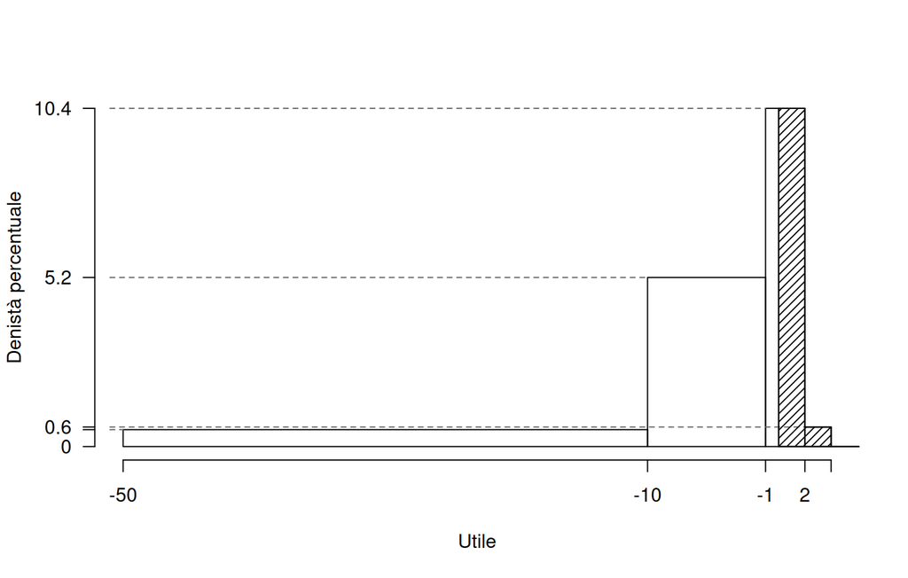

1.b **(Punti 3/56; 1.66/31)** Calcolare il numero di imprese con utile positivo

$$\begin{eqnarray*}
\%(X> 0 ) &=& ( 2 - 0 )\times h_{ 3 }+ f_{ 4 }\times 100
\\
&=& ( 2 )\times 10.4 + ( 0.012 )\times 100 \\
&=& 0.22 \times(100)\\
\#(X> 0 ) &\approx& 110
\end{eqnarray*}$$

1.c **(Punti 2/56; 1.11/31)** Individuare la classe modale, metterla in relazione con la mediana calcolata al punto 1a. La media aritmetica è maggiore o minore della mediana? Perché?

1.d **(Punti 2/56; 1.11/31)** Si consideri la funzione
$$g(x) = (2-x)+(3-x)+(6-x)$$
Per quale valore di $x$, $g(x)=0$?

### Esercizio 2

Due centri logistici, uno a Bologna e uno a Verona, registrano ogni giorno i tempi medi di consegna dei propri corrieri, espressi in minuti. A Bologna, il tempo medio di consegna è distribuito secondo $X \sim N(48, 9)$, mentre a Verona, il tempo medio è distribuito secondo $Y \sim N(42, 16)$, $X$ e $Y$ indipendenti. Il centro di Bologna è considerato in ritardo se il tempo medio supera i 52 minuti $A=\{X>52\}$; quello di Verona è considerato in ritardo se supera i 46 minuti $B=\{Y>46\}$.

2.a **(Punti 14/56; 7.75/31)** Calcolare la probabilità che entrambi i centri risultino in ritardo in un giorno.

$$\begin{eqnarray*}
P( X > 52 )
&=& P\left( \frac { X - \mu_X }{ \sigma_X
} > \frac { 52 - 48 }{\sqrt{ 9 }} \right) \\
&=& P\left( Z > 1.33 \right)
\\ &=& 1-P(Z< 1.33 )\\
&=& 1-\Phi( 1.33 ) \\ &=& 0.0918
\end{eqnarray*}$$
$$\begin{eqnarray*}
P( Y > 46 )
&=& P\left( \frac { Y - \mu_Y }{ \sigma_Y
} > \frac { 46 - 42 }{\sqrt{ 16 }} \right) \\
&=& P\left( Z > 1 \right)
\\ &=& 1-P(Z< 1 )\\
&=& 1-\Phi( 1 ) \\ &=& 0.1587
\end{eqnarray*}$$

$$\begin{eqnarray*}
P(A\cap B) &=& P(A)P(B)\\
&=& 0.0146
\end{eqnarray*}$$

2.b **(Punti 3/56; 1.66/31)** Sia $X \sim N(48, 9)$, sapendo che $C=\{X>48\}$ qual è la probabilità di $A=\{X>52\}$ ($P(A|C)$)?

2.c **(Punti 2/56; 1.11/31)** Siano $X\sim \text{Pois}(\lambda=1.6)$ e $Y\sim \text{Pois}(\lambda=2.1)$, $X$ e $Y$ indipendenti. Come si distribuisce
$$X+Y~~~?$$

$$X+Y \sim\text{Pois}(\lambda=1.6+2.1)$$

2.d **(Punti 2/56; 1.11/31)** Sia $X$ una VC e siano $A=\{X\le 10\}$ e $B=\{X > 35\}$. Posto $P(A)=0.15$ e $P(B)=0.05$, calcolare $P(\bar A\cup B)$. (suggerimento: individuare $A$ e $B$ sulla retta reale)

$$\begin{eqnarray*}
P( A\cup B) &=& P(\overline{\{X\le 10\}}\cup{X > 35})\\
&=& P(\{X> 10\}\cup{X > 35})\\
&=& P(X> 10)\\
&=& 1-P(X\le 10)\\
&=& 0.85
\end{eqnarray*}$$

### Esercizio 3

3.a **(Punti 14/56; 7.75/31)** Un’urna contiene 2 palline numerate con $\fbox{0}$, 3 numerate con $\fbox{1}$ e 2 numerate con $\fbox{2}$. Si estrae 100 volte con reinserimento. Qual è la probabilità che la media delle 100 estrazioni sia maggiore di 0.95?

$$\begin{eqnarray*} \mu &=& E(X_i)
= \sum_{x\in S_X}x P(X=x)\\
&=& 0 \frac { 2 }{ 7 }+ 1 \frac { 3 }{ 7 }+ 2 \frac { 2 }{ 7
} \\
&=& 1 \\
\sigma^2 &=& V(X_i) = \sum_{x\in S_X}x^2 P(X=x)-\mu^2\\
&=&\left( 0 ^2\frac { 2 }{ 7 }+ 1 ^2\frac { 3 }{ 7 }+
2 ^2\frac { 2 }{ 7 } \right)-( 1 )^2\\
&=& 0.5714
\end{eqnarray*}$$
**Teorema del Limite Centrale (media VC qualunque)**

Siano $X_1$,…,$X_n$, $n=100$ VC IID, tc $E(X_i)=\mu=1$ e $V(X_i)=\sigma^2=0.5714,\forall i$, posto:
$$\bar X=\frac{S_n}n =\frac{X_1 + ... + X_n}n$$
allora:
$$\begin{eqnarray*}
\bar X & \mathop{\sim}\limits_{a}& N(\mu,\sigma^2/n) \\
&\sim & N\left(1,\frac{0.5714}{100}\right) \\
&\sim & N(1,0.005714)
\end{eqnarray*}$$
$$\begin{eqnarray*}
P( \bar X > 0.95 )
&=& P\left( \frac { \bar X - \mu }{ \sqrt{\sigma^2/n}
} > \frac { 0.95 - 1 }{\sqrt{ 0.005714 }} \right) \\
&=& P\left( Z > -0.66 \right)
\\ &=& 1-P(Z< -0.66 )\\
&=& 1-(1-\Phi( 0.66 )) \\ &=& 0.7454
\end{eqnarray*}$$

## Prova di Statistica (CLEA E CLEAM)

Scrivere in stampatello

| COGNOME | $\LARGE\square$ | $\LARGE\square$ | $\LARGE\square$ | $\LARGE\square$ | $\LARGE\square$ | $\LARGE\square$ | $\LARGE\square$ | $\LARGE\square$ | $\LARGE\square$ | $\LARGE\square$ | $\LARGE\square$ | $\LARGE\square$ | $\LARGE\square$ | $\LARGE\square$ | $\LARGE\square$ | $\LARGE\square$ | $\LARGE\square$ | $\LARGE\square$ | $\LARGE\square$ | $\LARGE\square$ |
| --- | --- | --- | --- | --- | --- | --- | --- | --- | --- | --- | --- | --- | --- | --- | --- | --- | --- | --- | --- | --- |
| NOME | $\LARGE\square$ | $\LARGE\square$ | $\LARGE\square$ | $\LARGE\square$ | $\LARGE\square$ | $\LARGE\square$ | $\LARGE\square$ | $\LARGE\square$ | $\LARGE\square$ | $\LARGE\square$ | $\LARGE\square$ | $\LARGE\square$ | $\LARGE\square$ | $\LARGE\square$ | $\LARGE\square$ | $\LARGE\square$ | $\LARGE\square$ | $\LARGE\square$ | $\LARGE\square$ | $\LARGE\square$ |
| Matricola | $\LARGE\square$ | $\LARGE\square$ | $\LARGE\square$ | $\LARGE\square$ | $\LARGE\square$ | $\LARGE\square$ | $\LARGE\square$ | $\LARGE\square$ | $\LARGE\square$ | $\LARGE\square$ | $\LARGE\square$ | $\LARGE\square$ | $\LARGE\square$ | $\LARGE\square$ | $\LARGE\square$ | $\LARGE\square$ | $\LARGE\square$ | $\LARGE\square$ | $\LARGE\square$ | $\LARGE\square$ |
| Codice | A | F | 0 | M | N | 8 | J | Q |  |  |  |  |  |  |  |  |  |  |  |  |

### Esercizio 1

Un consorzio agroalimentare ha monitorato l’ammontare delle vendite mensili (in migliaia di euro) di un campione di 50 aziende agricole del Centro Italia, nel corso dell’anno 2023. Di seguito è riportata la distribuzione delle frequenze cumulate, raggruppate in classi di vendita.

| $[\text{x}_j,$ | $\text{x}_{j+1})$ | $F_j$ |
| --- | --- | --- |
| 0 | 5 | 0.06 |
| 5 | 7 | 0.34 |
| 7 | 8 | 0.66 |
| 8 | 10 | 0.94 |
| 10 | 15 | 1.00 |

1.a **(Punti 14/56; 7.75/31)** Disegnare l’istogramma delle densità percentuali.

| $[\text{x}_j,$ | $\text{x}_{j+1})$ | $n_j$ | $f_j$ | $b_j$ | $h_j$ |
| --- | --- | --- | --- | --- | --- |
| 0 | 5 | 3 | 0.06 | 5 | 1.2 |
| 5 | 7 | 14 | 0.28 | 2 | 14.0 |
| 7 | 8 | 16 | 0.32 | 1 | 32.0 |
| 8 | 10 | 14 | 0.28 | 2 | 14.0 |
| 10 | 15 | 3 | 0.06 | 5 | 1.2 |
|  |  | 50 | 1.00 | 15 |  |

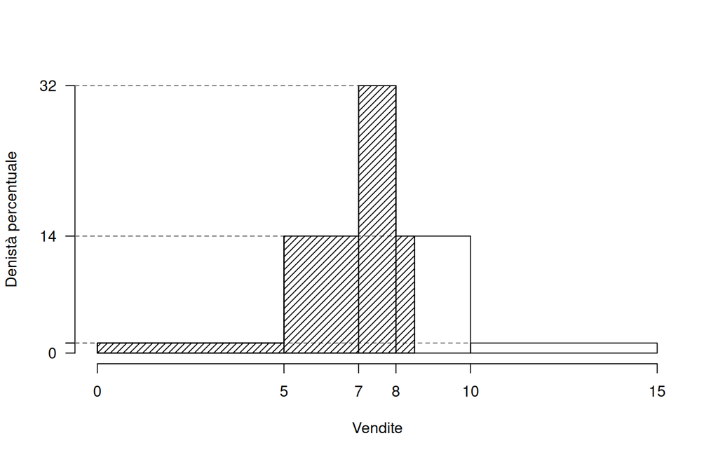

1.b **(Punti 3/56; 1.66/31)** Qual è la percentuale di aziende che hanno venduto meno di 8.5 mila euro?

$$\begin{eqnarray*}
\%(X< 8.5 ) &=& f_{ 1 }\times 100+f_{ 2 }\times 100+f_{
3 }\times 100 +( 8.5 - 8 )\times h_{ 4 } \\
&=& ( 0.06 )\times 100+( 0.28 )\times 100+( 0.32
)\times 100 +( 0.5 )\times 14 \\
&=& 0.73 \times(100) \\
\#(X< 8.5 ) &\approx& 36
\end{eqnarray*}$$

1.c **(Punti 2/56; 1.11/31)** Che relazione dobbiamo aspettarci tra media, mediana e moda?

1.d **(Punti 2/56; 1.11/31)** Si consideri la funzione
$$g(x) = |7-x|+|3-x|+|5-x|$$
Per quale valore di $x$, $g$ è minima?

### Esercizio 2

Un’azienda che produce macchinari per imballaggio ha due stabilimenti $A$ e $B$, nello stabilimento $A$ il numero di macchinari prodotti a settimana è distribuito come una Poisson di parametro 1.5 $X_A\sim\text{Pois}(1.5)$, mentre nello stabilimento $B$ il numero di macchinari prodotti a settimana è distribuito come una Poisson di parametro 0.8 $X_B\sim\text{Pois}(0.8)$, $X_A$ e $X_B$ indipendenti.

2.a **(Punti 14/56; 7.75/31)** Calcolare la probabilità che il totale prodotto ($X_A + X_B$) in una settimana sia maggiore o uguale a due.

$$X_A + X_B \sim \text{Pois}(1.5+0.8)$$
$$\begin{eqnarray*}
P( X_A+X_B \geq 2 ) &=& 1-P( X_A+X_B < 2 )
\\ &=& 1-\left( \frac{ 2.3 ^{ 0 }}{ 0 !}e^{- 2.3
}+\frac{ 2.3 ^{ 1 }}{ 1 !}e^{- 2.3 }
\right)\\ &=& 1-( 0.1003+0.2306
)\\ &=& 1- 0.3309
\\ &=& 0.6691
\end{eqnarray*}$$

2.b **(Punti 3/56; 1.66/31)** Sapendo $E=\{X_A + X_B \ge 1\}$ qual è la probabilità che $F=\{X_A + X_B \ge 2\}$ ($P(F|E)$)?

$$\begin{eqnarray*}
X_A + X_B &\sim& \text{Pois}(1.5 + 0.8) = \text{Pois}(2.3)\\
F \cap E &=& \{X_A + X_B \ge 2\}\\
\end{eqnarray*}$$

$$\begin{eqnarray*}
P(F \mid E) &=& \frac{P(F \cap E)}{P(E)}\\
&=& \frac{P(X_A + X_B \ge 2)}{P(X_A + X_B \ge 1)}\\
&=& \frac{0.6691}{0.8997}\\
&=& 0.7437
\end{eqnarray*}$$

2.c **(Punti 2/56; 1.11/31)** Sia $Z\sim N(0,1)$ e $Y\sim \chi^2_{n-1}$, dove $n\ge 2$ è un numero intero, $Z$ e $Y$ indipendenti. Come si distribuisce
$$\frac{Z}{\sqrt{\frac {Y}{n-1}}}\sim ~~~?$$

$$\frac{Z}{\sqrt{\frac {Y}{n-1}}}\sim t_{n-1} ~~~~ \text{è una $t$ di
Sudent con $n-1$ gradi di libertà}$$

### Esercizio 3

3.a **(Punti 14/56; 7.75/31)** Un’urna contiene 2 palline numerate con $\fbox{0}$, 3 numerate con $\fbox{1}$ e 2 numerate con $\fbox{2}$. Si estrae 1000 volte con reinserimento. Qual è la probabilità che la somma delle 1000 estrazioni sia maggiore di 976?

$$\begin{eqnarray*} \mu &=& E(X_i)
= \sum_{x\in S_X}x P(X=x)\\
&=& 0 \frac { 2 }{ 7 }+ 1 \frac { 3 }{ 7 }+ 2 \frac { 2 }{ 7
} \\
&=& 1 \\
\sigma^2 &=& V(X_i) = \sum_{x\in S_X}x^2 P(X=x)-\mu^2\\
&=&\left( 0 ^2\frac { 2 }{ 7 }+ 1 ^2\frac { 3 }{ 7 }+
2 ^2\frac { 2 }{ 7 } \right)-( 1 )^2\\
&=& 0.5714
\end{eqnarray*}$$
**Teorema del Limite Centrale (somma VC qualunque)**

Siano $X_1$,…,$X_n$, $n=1000$ VC IID, tc $E(X_i)=\mu=1$ e $V(X_i)=\sigma^2=0.5714,\forall i$, posto:
$$S_n = X_1 + ... + X_n$$
allora:
$$\begin{eqnarray*}
S_n & \mathop{\sim}\limits_{a}& N(n\mu,n\sigma^2) \\
&\sim & N(1000\cdot1,1000\cdot0.5714) \\
&\sim & N(1000,571.4)
\end{eqnarray*}$$
$$\begin{eqnarray*}
P( S_n > 976 )
&=& P\left( \frac { S_n - n\mu }{ \sqrt{n\sigma^2}
} > \frac { 976 - 1000 }{\sqrt{ 571.4 }} \right) \\
&=& P\left( Z > -1 \right)
\\ &=& 1-P(Z< -1 )\\
&=& 1-(1-\Phi( 1 )) \\ &=& 0.8413
\end{eqnarray*}$$